# Einführung in die Darstellung und Interpolation von räumlicher Daten mit R

## Interpolation - Kriging

- Der Vorteil gegenüber einfacheren Methoden wie beispielsweise der Inversen Distanzgewichtung ist die Berücksichtigung der räumlichen Varianz. (Wikipedia)

```r
lead.kriged = krige(logLead ~ 1, meuse, meuse.grid, model = lead.vgm.fit)
lead.kriged$expVar1.pred <- exp(lead.kriged$var1.pred)
```

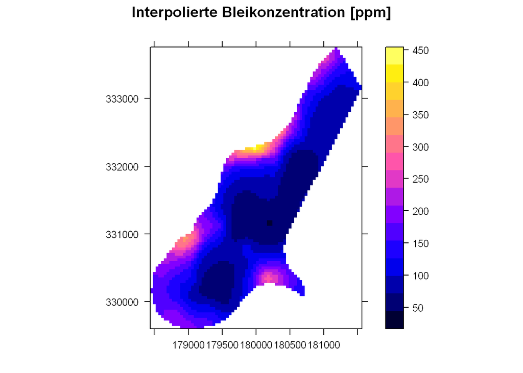

```r
# [using ordinary kriging]
spplot(lead.kriged["expVar1.pred"], scales=list(draw=T), main ="Interpolierte Bleikonzentration [ppm]")
```

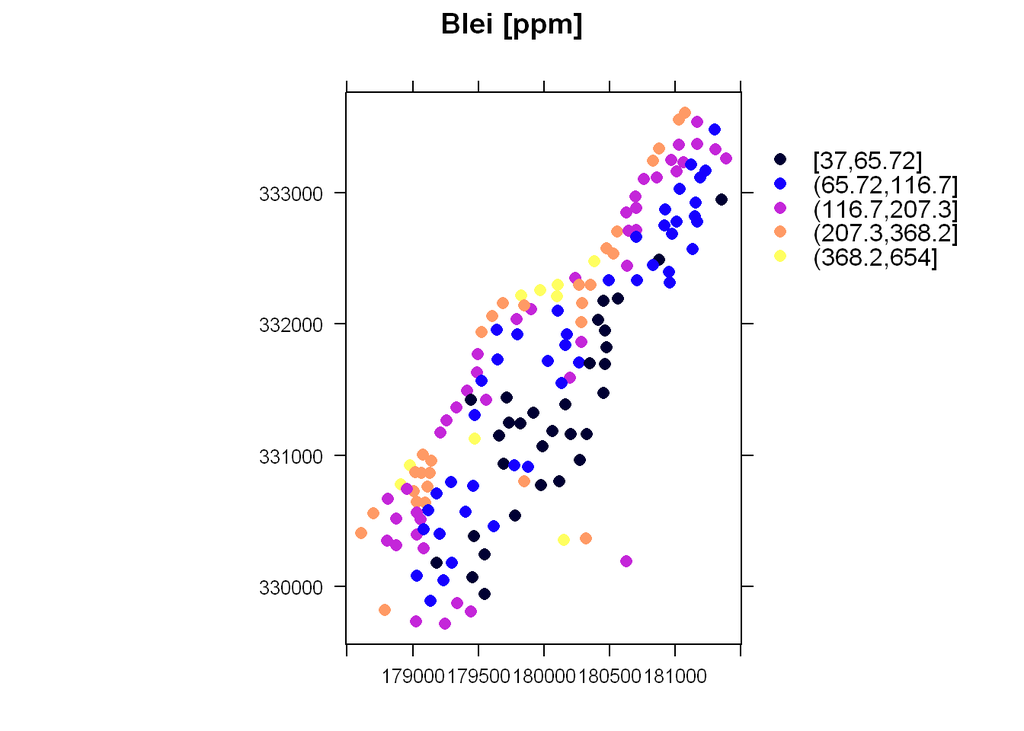

```r
spplot(meuse, "lead", do.log = TRUE,
    key.space=list(x=1.05,y=0.9,corner=c(0,1)),
    scales=list(draw=T),
    main = "Blei [ppm]")
```

## Referenzen/Online Ressourcen

- Applied Spatial Data Analysis with R, Roger S. Bivand, Edzer Pebesma and V. Gómez-Rubio, UseR! Series, Springer, 2nd ed. 2013, xviii+405 pp., ISBN: 978-1-4614-7617-7
- Handling and Analyzing Spatial, Spatiotemporal and Movement Data, Edzer Pebesma 27 June, 2016: https://edzer.github.io/UseR2016/
- Leafleat und Meuse: http://rpubs.com/pcormeau/meuse
- Variogramm und Kriging: https://cran.r-project.org/web/packages/gstat/vignettes/gstat.pdf
- Übersicht: https://cran.r-project.org/web/views/Spatial.html

### Datensatz

- https://rweb.stat.umn.edu/R/site-library/sp/html/meuse.html
- https://rweb.stat.umn.edu/R/site-library/sp/html/meuse.grid.html